# Project 1 - Predicting the downloads of mobile app ads. Data Science Academy

```r
# Setting the working directory
setwd("D:/FCD/Projetos/Projeto-Feedback1")

# Packages for loading and manipulating the data
library(data.table)
library(lubridate)
library(dplyr)
library(reshape)
```

```r
# Packages for visualization
library(ggplot2)
library(gridExtra)
library(forcats)

# Categorical variables association
library(GoodmanKruskal)

# Packages for splitting the data and machine learning
library(randomForest)
library(class)
library(e1071)
library(caTools)
library(ROSE)
library(caret)
library(C50)
library(PRROC)
# Importing functions created for this project
source("src/FuncTools.R")

# Importing the train data
train <- fread('train_sample.csv')

# First lines of the data
head(train)
```

```
##        ip app device os channel          click_time attributed_time
## 1:  87540  12      1 13     497 2017-11-07 09:30:38
## 2: 105560  25      1 17     259 2017-11-07 13:40:27
## 3: 101424  12      1 19     212 2017-11-07 18:05:24
## 4:  94584  13      1 13     477 2017-11-07 04:58:08
## 5:  68413  12      1  1     178 2017-11-09 09:00:09
## 6:  93663   3      1 17     115 2017-11-09 01:22:13
##    is_attributed
## 1:             0
## 2:             0
## 3:             0
## 4:             0
## 5:             0
## 6:             0
```

```r
# Dimensions of the data
dim(train)
```

```
## [1] 100000      8
```

## Data description

- ip: ip address of click.
- app: app id for marketing.
- device: device type id of user mobile phone (e.g., iphone 6 plus, iphone 7, huawei mate 7, etc.)
- os: os version id of user mobile phone
- channel: channel id of mobile ad publisher
- click_time: timestamp of click (UTC)
- attributed_time: if user download the app after clicking an ad, this is the time of the app download
- is_attributed: the target that is to be predicted, indicating the app was downloaded Note that ip, app, device, os, and channel are encoded.

```r
# Searching for missing values
sapply(train, function(x){sum(is.na(x))})
```

```
##              ip             app          device              os         channel
##               0               0               0               0               0
##      click_time attributed_time   is_attributed
##               0               0               0
```

No missing values were detected, but there are rows with no values in column attributed_time marked with double quotes, that is why missing values for that column were not returned. At first, this may not be a problem because in further manipulations this will be treated. We can also notice that features as ip, app, device, os, channel and is_attibuted are categorical variables. These variables will be further properly transformed into categorical type.

```r
## Adding new features to be used in the descriptive analysis
train <- train %>%
  mutate(datetime = as.POSIXct(click_time, format = "%Y-%m-%d %H:%M:%S"),
         date = as.Date(datetime),
         wday = wday(date),
         hour = hour(datetime),
         minute = lubridate::minute(datetime),
         attribute_POSIX = as.POSIXct(attributed_time, format = "%Y-%m-%d %H:%M:%S"),
         date_download = as.Date(attribute_POSIX),
         hour_download = hour(attribute_POSIX),
         ip_range = cut(ip, breaks = c(0,120000,210000,364757), labels = c(1,2,3)))
str(train)
```

```
## Classes 'data.table' and 'data.frame':   100000 obs. of  17 variables:
##  $ ip             : int  87540 105560 101424 94584 68413 93663 17059 121505 192967 143636 ...
##  $ app            : int  12 25 12 13 12 3 1 9 2 3 ...
##  $ device         : int  1 1 1 1 1 1 1 1 2 1 ...
##  $ os             : int  13 17 19 13 1 17 17 25 22 19 ...
##  $ channel        : int  497 259 212 477 178 115 135 442 364 135 ...
##  $ click_time     : chr  "2017-11-07 09:30:38" "2017-11-07 13:40:27" "2017-11-07 18:05:24" "2017-11-07 04:58:08" ...
##  $ attributed_time: chr  "" "" "" "" ...
##  $ is_attributed  : int  0 0 0 0 0 0 0 0 0 0 ...
##  $ datetime       : POSIXct, format: "2017-11-07 09:30:38" "2017-11-07 13:40:27" ...
##  $ date           : Date, format: "2017-11-07" "2017-11-07" ...
##  $ wday           : num  3 3 3 3 5 5 5 3 4 4 ...
##  $ hour           : int  9 13 18 4 9 1 1 10 9 12 ...
##  $ minute         : int  30 40 5 58 0 22 17 1 35 35 ...
##  $ attribute_POSIX: POSIXct, format: NA NA ...
##  $ date_download  : Date, format: NA NA ...
##  $ hour_download  : int  NA NA NA NA NA NA NA NA NA NA ...
##  $ ip_range       : Factor w/ 3 levels "1","2","3": 1 1 1 1 1 1 1 2 2 2 ...
##  - attr(*, ".internal.selfref")=<externalptr>
```

ip_range: ip grouped by bins (0,1.2e+05], (1.2e+05,2.1e+05], (2.1e+05,3.65e+05] -> lables 1, 2, 3 respectively.

## Descriptive Analysis

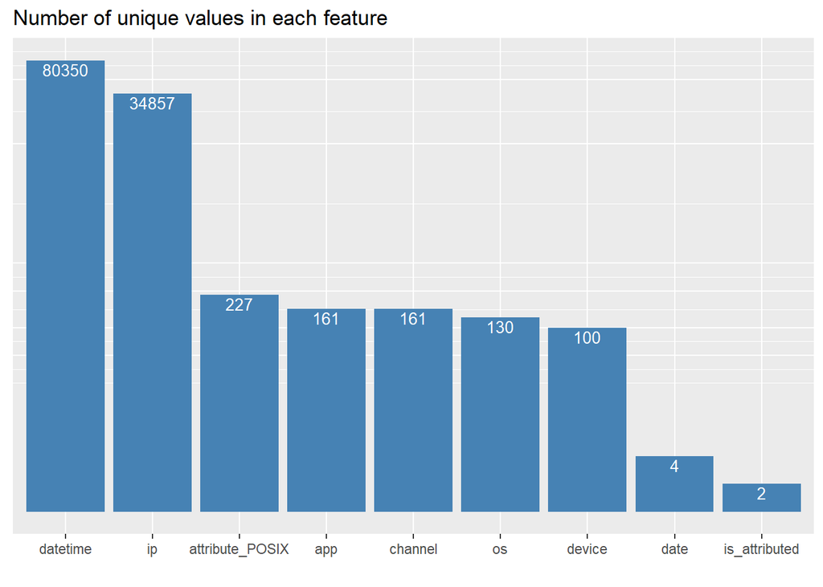

```r
## Number of unique values in each feature
cols = c('ip','app','device','os','channel','datetime','attribute_POSIX', 'date','is_attributed')
train %>% summarize_at(cols, n_distinct, na.rm = TRUE) %>%
  data.table::melt(variable.name = "features", value.name = "unique_values") %>%
  ggplot(aes(reorder(features, -unique_values), unique_values)) +
  geom_bar(stat = "identity", fill = "steelblue") +
  scale_y_log10(breaks = c(50,100,250, 500, 10000, 50000)) +
  geom_text(aes(label = unique_values), vjust = 1.2, color = "white", size=3.5) +
  theme(axis.title.y=element_blank(),
        axis.text.y=element_blank(),
        axis.ticks.y=element_blank()) +
  ggtitle('Number of unique values in each feature') +
  labs(x = '', y = '')
```

## Exploring date column

It is known from the former visualization that there are 4 unique values in date column, which means that data presented in train dataset is from four different days: 2017/11/06-09.

```r
unique(train$date)
```

```
## [1] "2017-11-07" "2017-11-09" "2017-11-08" "2017-11-06"
```

## Exploring is_attributed column

What is the amount of downloads?

```r
table(train$is_attributed)
```

```
##
##     0     1
## 99773   227
```

227 downloads from 100000 clicks.

Visualizing the proportion between downloads and clicks.

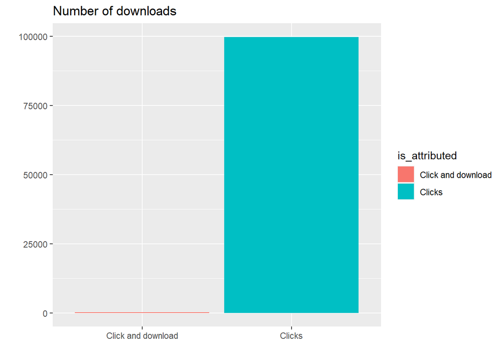

```r
train %>% group_by(is_attributed) %>%
  summarise(n = n()) %>%
  mutate(is_attributed = ifelse(is_attributed == 0, 'Clicks', 'Click and download')) %>%
  ggplot(aes(x = is_attributed, y = n, fill = is_attributed)) +
  geom_bar(stat = 'identity') +
  ggtitle('Number of downloads') +
  xlab('')+
  ylab('')
```

Only 0.227% of the clicks resulted in the download of the product. Thus, the classes are imbalanced, which have adverse effects on learning process, like: 1. Problems of performance (like accuracy) -> evaluation metrics guide the learning of the algorithm. The evaluation metrics do not take the minority class into account, then the predictions of these class will be compromised. 2. The second problem is related with the lack of data for the minor class, which turns difficult to construct accurate decisions boundaries between classes and uncover regularities within the small class. 3. Standard ML algorithms tends to treat minority classes as noise. Thus, class imbalance will have to be treated before training the algorithm.

## What time did the downloads occurr?

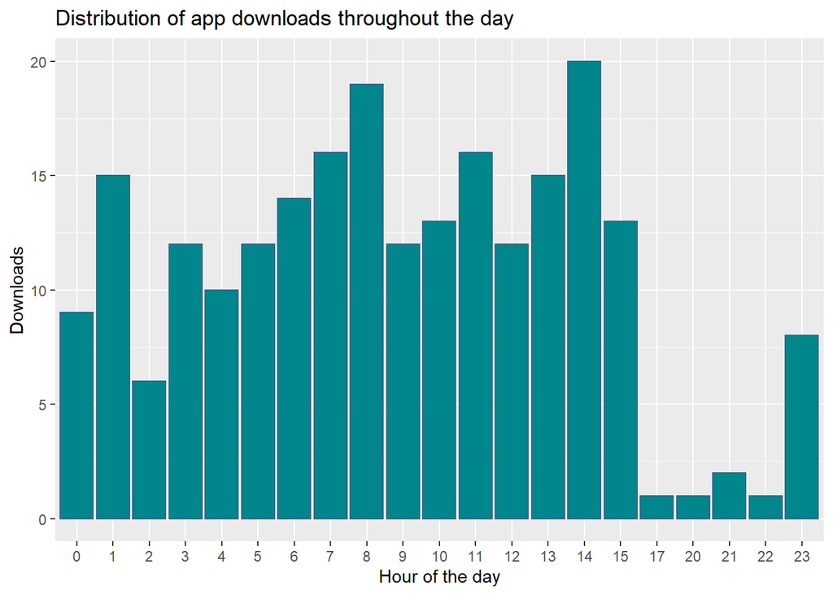

```r
train %>% filter(hour_download != 'NA') %>%
  group_by(hour_download) %>%
  summarise(n = n()) %>%
  ggplot(aes(x = as.factor(hour_download), y = n)) +
  geom_bar(stat = 'identity', fill='turquoise4', color="steelblue4") +
  ggtitle('Distribution of app downloads throughout the day') +
  xlab('Hour of the day') +
  ylab('Downloads')
```

Number of downloads reduced between 17:00-22:00 and no downloads were observed at 16:00, 18:00 and 19:00.

## Distribution of clicks throughout the 4 days.

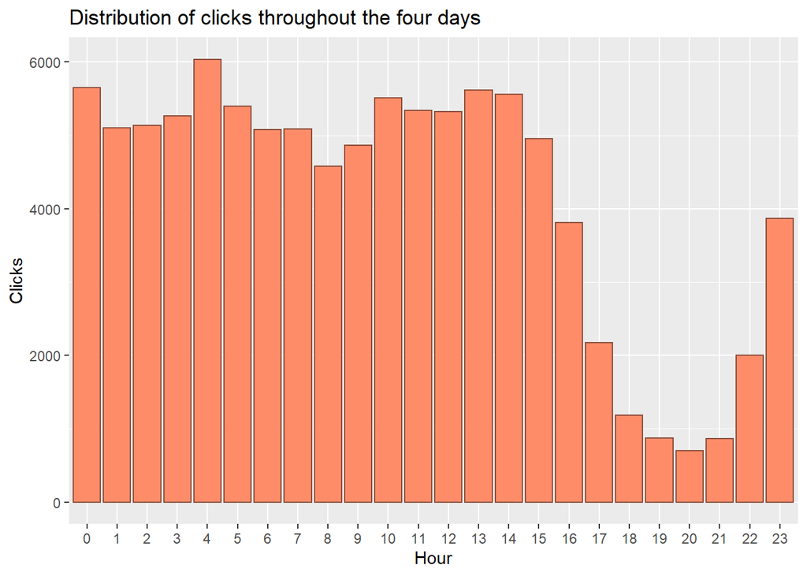

```r
train %>% group_by(hour) %>%
  summarise(n = n()) %>%
  ggplot(aes(x = as.factor(hour), y = n)) +
  geom_bar(stat = 'identity', fill = 'salmon1', color = 'salmon4') +
  ggtitle('Distribution of clicks throughout the four days') +
  xlab('Hour') +
  ylab('Clicks')
```

# Next visualization shows the amount of clicks per minute.

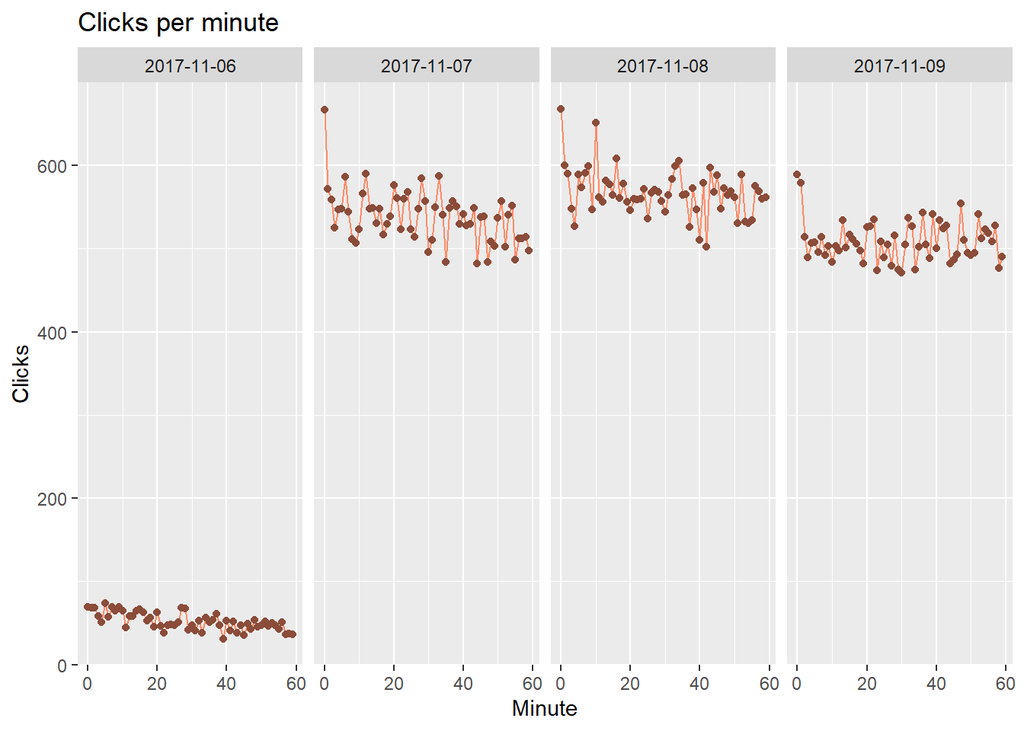

```r
train %>% group_by(date, minute) %>%
  summarise(n = n()) %>%
  ggplot(aes(x = minute, y = n)) +
  geom_line(color = 'salmon1') +
  geom_point(color = 'salmon4') +
  facet_grid(. ~ date) +
  ggtitle('Clicks per minute') +
  xlab('Minute') +
  ylab('Clicks')
```

# Downloads in each minute

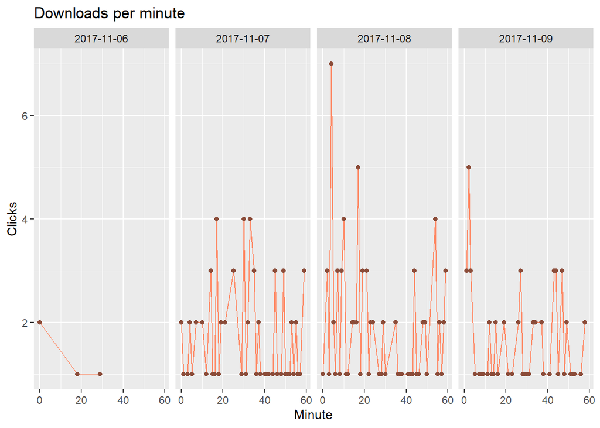

```r
train %>% filter(is_attributed == 1) %>%
  group_by(date, minute) %>%
  summarise(n = n()) %>%
  ggplot(aes(x = minute, y = n)) +
  geom_line(color = 'salmon1') +
  geom_point(color = 'salmon4') +
  facet_grid(. ~ date) +
  ggtitle('Downloads per minute') +
  xlab('Minute') +
  ylab('Clicks')
```

The ad received an average of 1667 clicks per minute in 4 days.

```r
train %>% group_by(minute) %>%
  summarise(n = n()) %>%
  summarise(total = mean(n))
```

```
## # A tibble: 1 x 1
##   total
##   <dbl>
## 1 1667.
```

# Number of clicks per day.

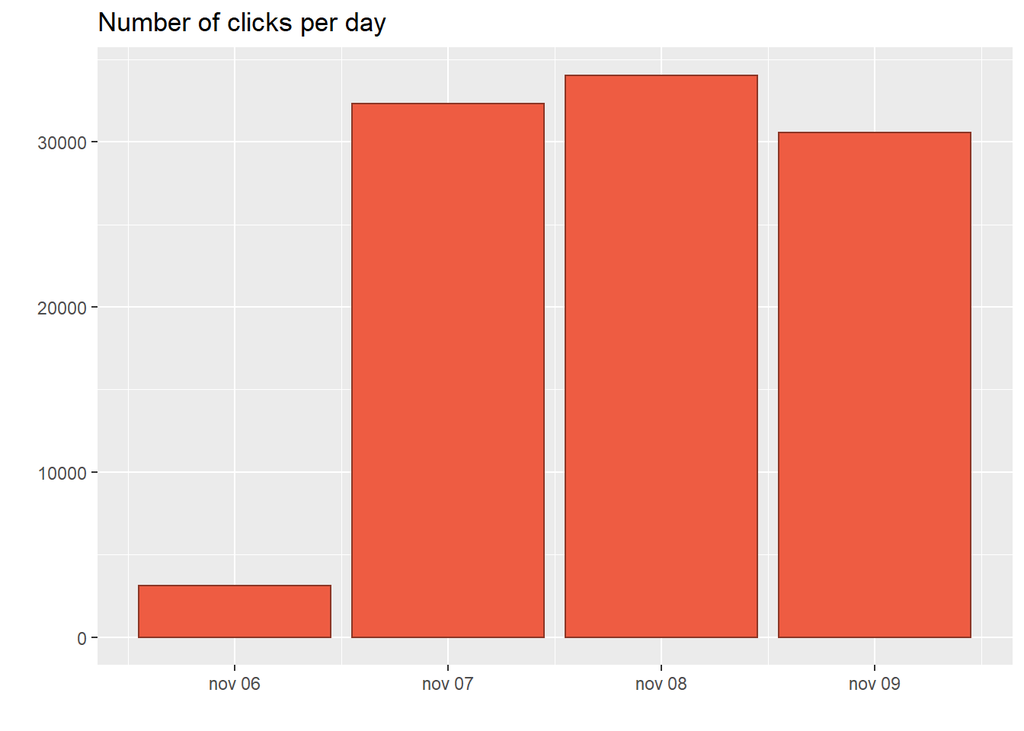

```r
train %>% group_by(date) %>%
  summarise(total = n()) %>%
  ggplot(aes(x = date, y = total, fill = date)) +
  geom_bar(stat = 'identity', fill = 'tomato2', color = 'tomato4') +
  ggtitle('Number of clicks per day') +
  xlab('')+
  ylab('')
```

The first day had approximately 90% less clicks compared to the other days. In this day, clicks were recorded from 16:00 to 21:59:50.

```r
train %>% filter(date == '2017-11-06') %>%
  summarise(min = min(datetime), max = max(datetime))
```

```
##                   min                 max
## 1 2017-11-06 16:00:00 2017-11-06 21:59:50
```

## Distribution of clicks in each day.

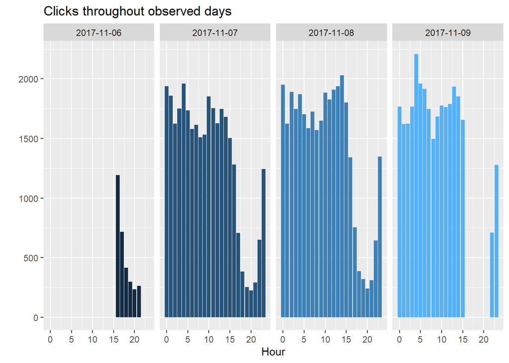

```r
ggplot(train, aes(x = hour, fill = date)) +
  geom_bar() +
  facet_grid(. ~ date) +
  ggtitle('Clicks throughout observed days') +
  xlab('Hour') +
  ylab('') +
  theme(legend.position = "none")
```

# Distribution of downloads in each day.

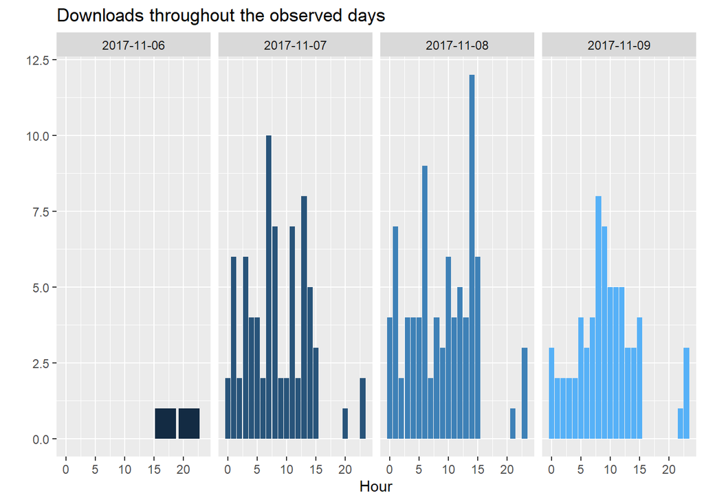

```r
train %>% filter(is_attributed == 1) %>%
  ggplot(aes(x = hour_download, fill = date_download)) +
  geom_bar() +
  facet_grid(. ~ date_download) +
  ggtitle('Downloads throughout the observed days') +
  xlab('Hour') +
  ylab('') +
  theme(legend.position = "none")
```

# Number of downloads per day.

```r
train %>% filter(is_attributed == 1) %>%
  group_by(date_download) %>%
  summarise(downloads = n())
```

```
## # A tibble: 4 x 2
##   date_download downloads
##   <date>            <int>
## 1 2017-11-06            2
## 2 2017-11-07           75
## 3 2017-11-08           84
## 4 2017-11-09           66
```

2017-11-06 presented only 2 downloads which makes sense, once the clicks in this day were between 16:00 to 22:00, hour range with lower clicks and lower downloads as well. Thus, it is noticeable that data is time dependent.

## Exploring IP column

There are 34857 unique IP, which means that part of the clicks came from the same IP. How many IP have more than 1 click?

```r
More_1_click <- train %>% group_by(ip) %>%
  summarise(n= n()) %>%
  filter(n > 1) %>%
  nrow()
Only_1_click <- train %>% group_by(ip) %>%
  summarise(n= n()) %>%
  filter(n == 1) %>%
  nrow()
rbind(Only_1_click,More_1_click)
```

```
##               [,1]
## Only_1_click 17423
## More_1_click 17434
```

17434 IPs have more than 1 click and 17423 IPs have only one click, i.e., half of the unique IPs has only 1 click.

# Top 10 IP considering clicks

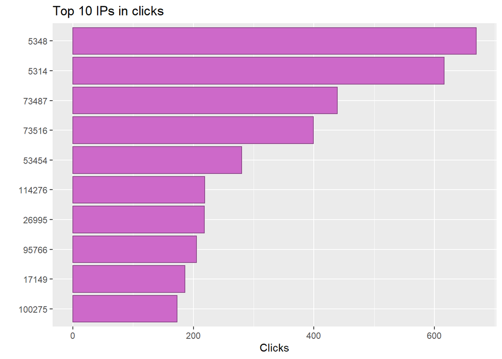

```r
train %>% group_by(ip) %>%
  summarise(n= n()) %>%
  arrange(desc(n)) %>%
  head(10) %>%
  mutate(IP = fct_reorder(as.factor(ip), n)) %>%
  ggplot(aes(x = n, y = IP)) +
  geom_bar(stat = 'identity', color = 'orchid4', fill = 'orchid3') +
  ggtitle('Top 10 IPs in clicks') +
  xlab('Clicks') +
  ylab('')
```

# Verifying if IP with more clicks presented downloads.

```r
train %>% filter(is_attributed == '1') %>%
  group_by(ip) %>%
  summarise(downloads_per_ip = n()) %>%
  group_by(downloads_per_ip) %>%
  summarise(number_of_occurrence = n())
```

```
## # A tibble: 2 x 2
##   downloads_per_ip number_of_occurrence
##              <int>                <int>
## 1                1                  221
## 2                3                    2
```

6 downloads came from 2 IP numbers; 221 downloads were made from different IP numbers.

```r
# preparing ips with more than 1 click
df <- train %>% group_by(ip) %>%
  summarise(n= n()) %>%
  filter(n > 1)
# inner_join train data with df by ip column
joined_ip <- train %>% filter(is_attributed == '1') %>%
  inner_join(df, by = 'ip')

nrow(joined_ip)
```

```
## [1] 77
```

77 downloads were made from IP numbers with more than 1 click.

```r
joined_ip %>%
  filter(n > 100) %>%
  group_by(ip, date_download) %>%
  summarize(total = n())
```

```
## # A tibble: 6 x 3
## # Groups:   ip [3]
##       ip date_download total
##    <int> <date>        <int>
## 1   5314 2017-11-07        1
## 2   5314 2017-11-08        2
## 3   5348 2017-11-07        1
## 4   5348 2017-11-08        1
## 5   5348 2017-11-09        1
## 6 111025 2017-11-07        1
```

Thus, IP with higher amount of clicks does not necessarily have more downloads. Next visualization shows the distribution of clicks and downloads throughout the IP numbers.

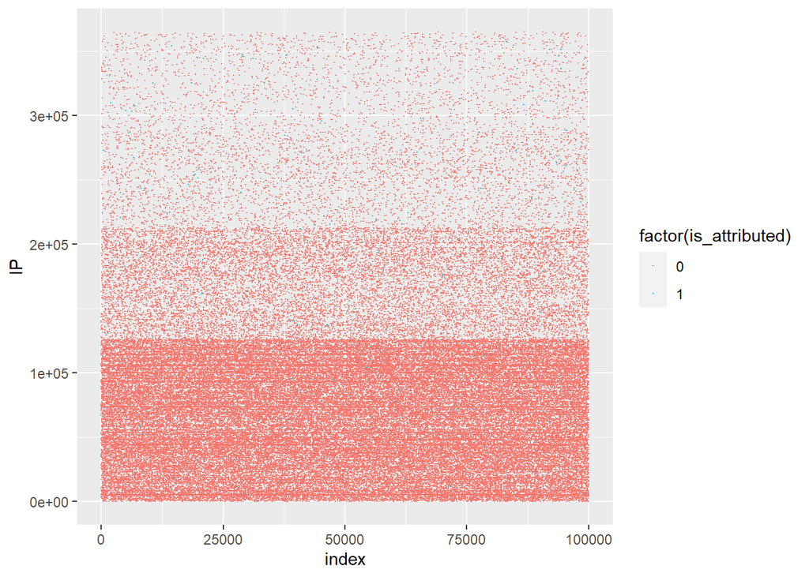

```r
p0 <- ggplot(train, aes(x = seq_along(ip), y = ip)) +
  geom_point(aes(col=factor(is_attributed)), alpha=0.8, size=0.05) +
  labs(x = 'index', y = 'IP')
p0
```

It’s observed that there are 3 ranges of IP numbers with different concentration of clicks: 0 - 120000; 120000 - 210000; 210000 - 360000 (approximated values). Clicks are more concentrated at the first range and decreases gradually in the second and the third ranges. On the other hand, the number of downloads are dispersed through all IP numbers, which is shown in the next visualization.

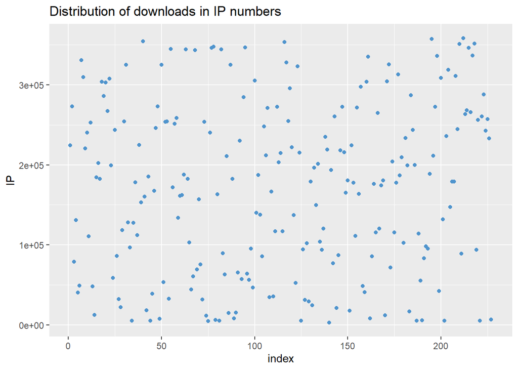

```r
p1 <- train %>% filter(is_attributed == 1) %>%
  ggplot(aes(x = seq_along(ip), y = ip)) +
  geom_point(color = 'steelblue3') +
  labs(x = 'index', y = 'IP') +
  ggtitle('Distribution of downloads in IP numbers')
p1
```

# Investigating the number of downloads in each IP range

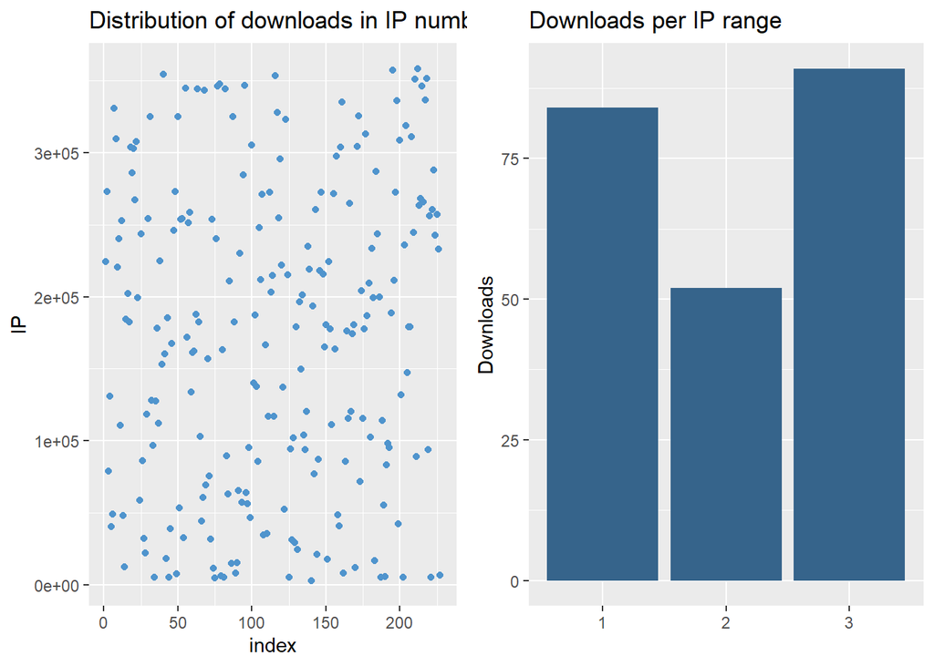

```r
p2 <- train %>% filter(is_attributed == 1) %>%
  group_by(ip_range) %>%
  count() %>%
  ggplot(aes(x = ip_range, y = n)) +
  geom_bar(stat = 'identity', fill = 'steelblue4') +
  labs(x = '', y = 'Downloads') +
  ggtitle('Downloads per IP range')
grid.arrange(p1, p2, ncol = 2)
```

# Exploring the distribution of IP numbers in each day.

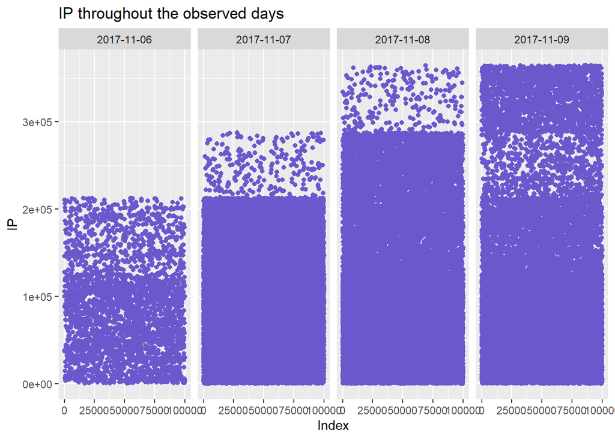

```r
train %>%
  ggplot(aes(x = seq_along(ip), y = ip)) +
  geom_point(color = 'slateblue3') +
  facet_grid(. ~ date) +
  ggtitle('IP throughout the observed days') +
  xlab('Index') +
  ylab('IP') +
  theme(legend.position = "none")
```

New IPs are registered every day. As time goes by, the earlier range of IP numbers keep getting more clicks, and new IP numbers appear.

Next visualization shows the ip range of clicks in each hour. It is noticeable that first IP range predominated over the other ranges.

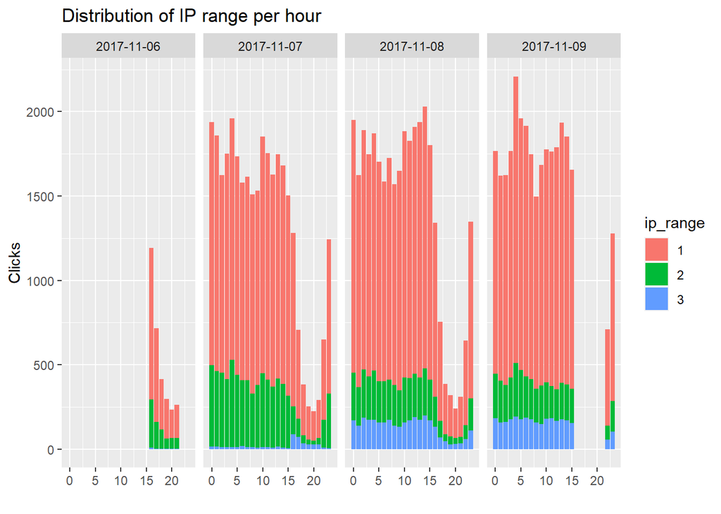

```r
train %>%
  group_by(ip_range, date, hour) %>%
  count() %>%
  ggplot(aes(x = hour, y = n, fill = ip_range)) +
  geom_bar(stat = 'identity') +
  facet_grid(.~ date) +
  labs(x = '', y = 'Clicks') +
  ggtitle('Distribution of IP range per hour')
```

An interesting observation is that, despite lower number of clicks, ip_range 3 presented more downloads than the others. Let’s compare the number of clicks and number of downloads for each ip_range.

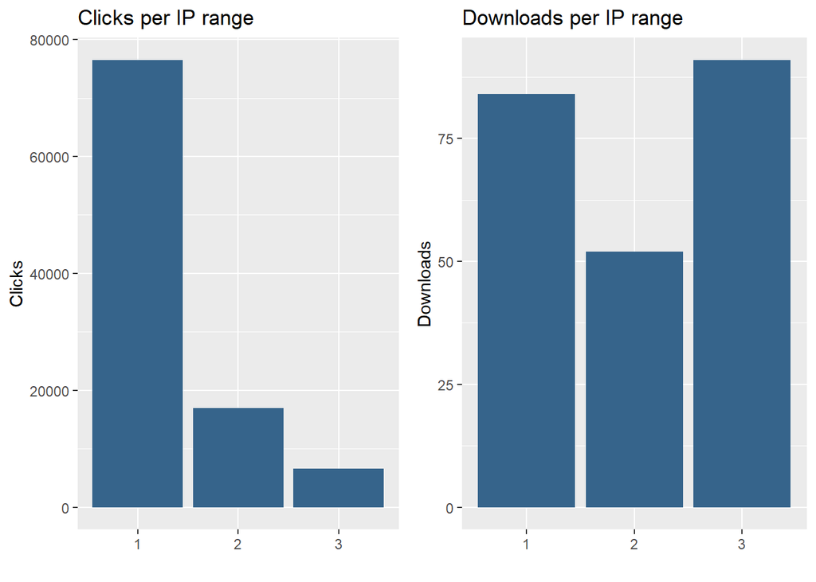

```r
p3 <- train %>%
  group_by(ip_range) %>%
  count() %>%
  ggplot(aes(x = ip_range, y = n)) +
  geom_bar(stat = 'identity', fill = 'steelblue4') +
  labs(x = '', y = 'Clicks') +
  ggtitle('Clicks per IP range')
grid.arrange(p3, p2, ncol = 2)
```

## Exploring app column

37 app had downloads. The next visualization shows the app that presented more than 3 downloads.

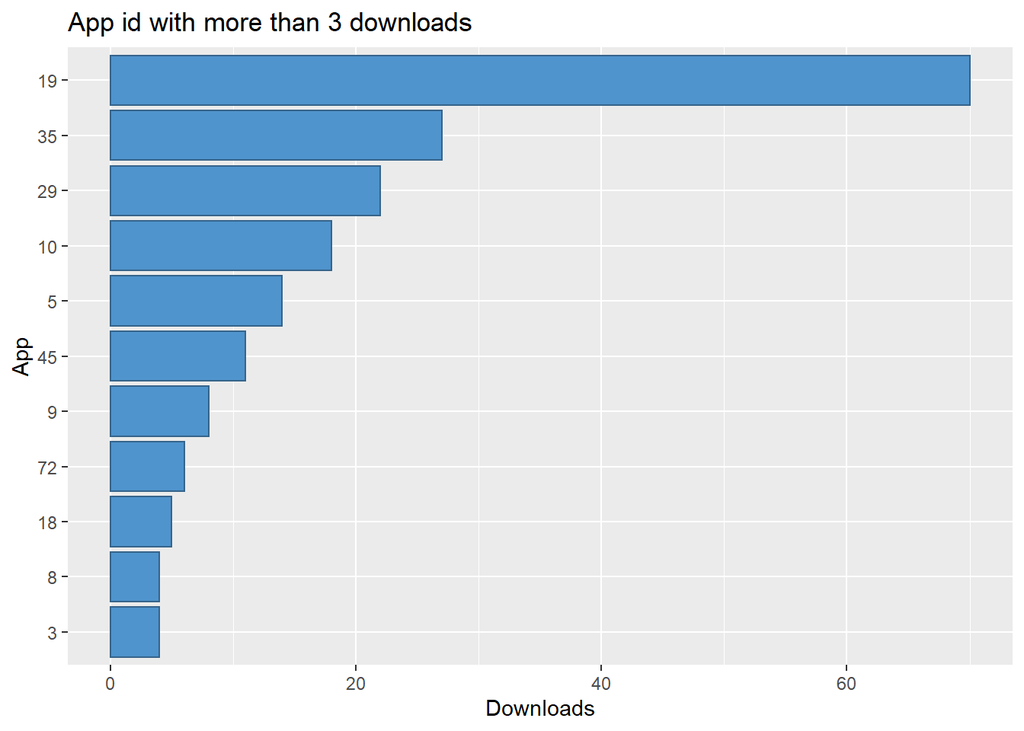

```r
train %>% filter(is_attributed == 1) %>%
  group_by(app) %>%
  summarise(total = n()) %>%
  filter(total > 3) %>%
  mutate(App_id = fct_reorder(as.factor(app), total)) %>%
  ggplot(aes(x = total, y = App_id)) +
  geom_bar(stat = 'identity', color ='steelblue4' , fill = 'steelblue3') +
  ggtitle('App id with more than 3 downloads') +
  ylab('App') +
  xlab('Downloads')
```

Top 10 app in clicks.

```r
app_group <- train %>% group_by(app) %>% summarise(total_clicks = n())
app_group %>% arrange(desc(total_clicks))
```

```
## # A tibble: 161 x 2
##      app total_clicks
##    <int>        <int>
##  1     3        18279
##  2    12        13198
##  3     2        11737
##  4     9         8992
##  5    15         8595
##  6    18         8315
##  7    14         5359
##  8     1         3135
##  9    13         2422
## 10     8         2004
## # ... with 151 more rows
```

The following visualization shows that the apps with most downloads were not the ones with the most clicks.

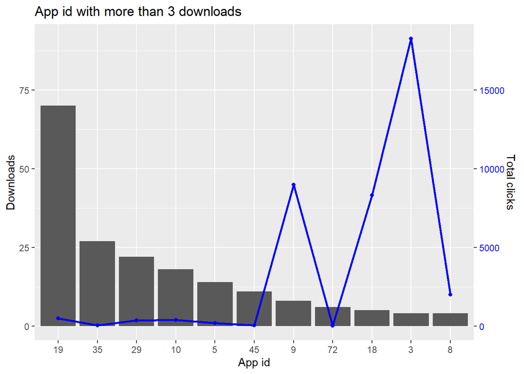

```r
train %>% filter(is_attributed == 1) %>%
  group_by(app) %>%
  summarise(total_downloads = n()) %>%
  inner_join(app_group, by = 'app') %>%
  mutate(app = fct_reorder(as.factor(app), desc(total_downloads))) %>%
  filter(total_downloads > 3) %>%
  ggplot(aes(x = app, y = total_downloads)) +
  geom_bar(stat = 'identity') +
  geom_line(aes(x = app, y = total_clicks/200, group = 1), size = 1, color="blue") +
  geom_point(aes(x = app, y = total_clicks/200), color = 'blue', size = 1.5) +
  scale_y_continuous(sec.axis = sec_axis(~.*200, name = "Total clicks")) +
  theme(axis.text.y.right = element_text(color = "blue")) +
  ggtitle('App id with more than 3 downloads') +
  ylab('Downloads') +
  xlab('App id')
```

## Exploring device column

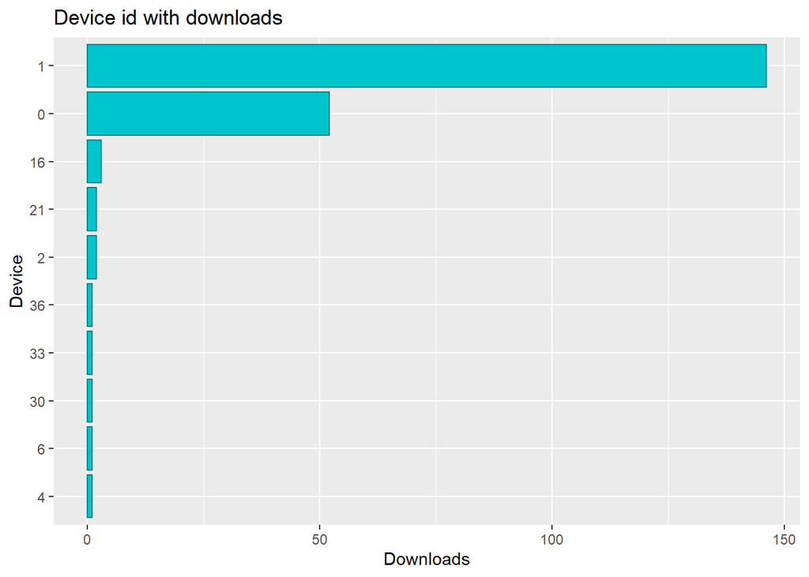

```r
train %>% filter(is_attributed == 1) %>%
  group_by(device) %>%
  summarise(total = n()) %>%
  mutate(factor = fct_reorder(as.factor(device), total)) %>%
  head(10) %>%
  ggplot(aes(x = total, y = factor)) +
  geom_bar(stat = 'identity', color = 'turquoise4', fill = 'turquoise3') +
  ggtitle('Device id with downloads') +
  ylab('Device') +
  xlab('Downloads')
```

25 of 100 devices had downloads. Device 0 and 1 had the most downloads.

Next visualization presents a comparison between the devices that presented the most clicks and the number of downloads in those devices. From the barplot we notice that around 94% of the clicks came from device 1, which was also responsible for the most downloads (64%) followed by device 0.

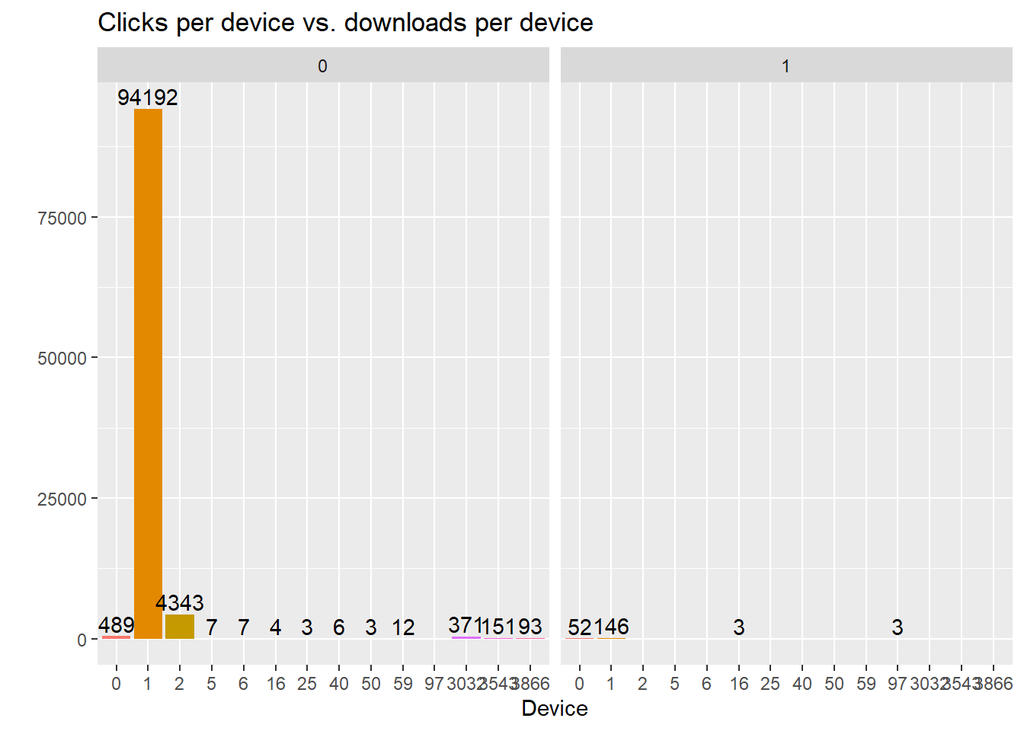

```r
train %>% group_by(is_attributed) %>%
  count(device) %>%
  arrange(desc(n), .by_group = TRUE) %>%
  filter(n > 2) %>%
  ggplot(aes(x = as.factor(device), y = n, fill = as.factor(device))) +
  geom_bar(stat = 'identity') +
  geom_text(aes(label=n), position=position_dodge(width=0.9), vjust=-0.25) +
  theme(legend.position = "none") +
  facet_grid(.~ is_attributed) +
  ggtitle('Clicks per device vs. downloads per device') +
  ylab('')+
  xlab('Device')
```

## Exploring os column

[figure not shown]

```r
p3 <- train %>% group_by(os) %>%
  count() %>%
  arrange(desc(n)) %>%
  head(10) %>%
  ggplot(aes(x = reorder(as.factor(os), -n), y = n)) +
  geom_bar(stat = 'identity', fill = 'steelblue3') +
  xlab('os') +
  ggtitle('5 os with most clicks')

p4 <- train %>% filter(is_attributed == 1) %>%
  group_by(os) %>%
  count() %>%
  arrange(desc(n)) %>%
  head(10) %>%
  ggplot(aes(x = reorder(as.factor(os), -n), y = n)) +
  geom_bar(stat = 'identity', fill = 'turquoise4') +
  xlab('os') +
  ggtitle('5 os with most downloads')
grid.arrange(p3, p4, ncol = 2)
```

## Exploring channel column

Let’s look at the distribution of clicks in those channels. All 161 channels had clicks, next visualization shows top 10 channels in clicks.

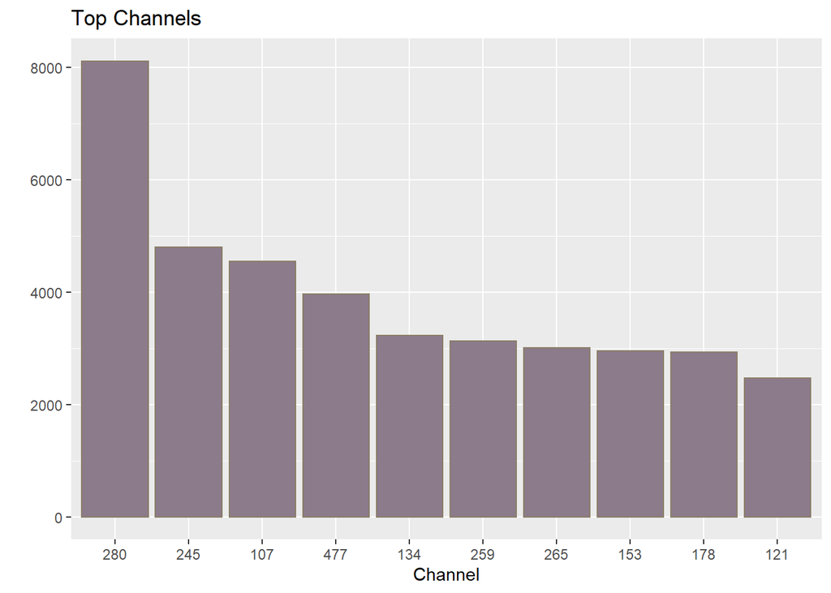

```r
train %>% group_by(channel) %>%
  count(channel) %>%
  mutate(channel = as.factor(channel)) %>%
  arrange(desc(n)) %>%
  head(10) %>%
  ggplot(aes(x = reorder(channel, -n), y = n)) +
  geom_bar(stat = 'identity', color = 'wheat4', fill = 'thistle4') +
  ggtitle('Top Channels') +
  xlab('Channel') +
  ylab('')
```

Distribution of click and downloads in channels.

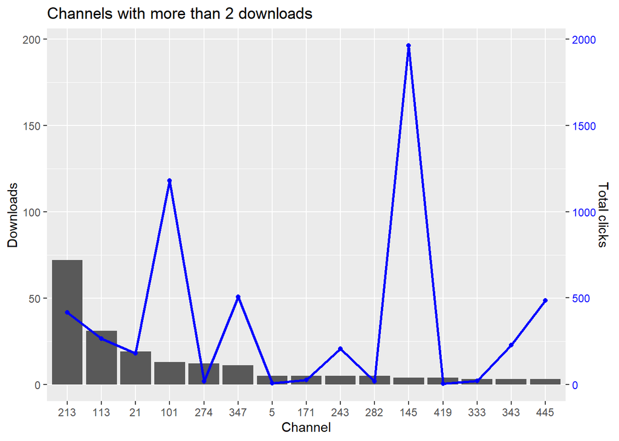

```r
df <- train %>% group_by(channel) %>%
  count(channel)

train %>% filter(is_attributed == 1) %>%
  group_by(channel) %>%
  summarise(total = n()) %>%
  inner_join(df, 'channel') %>%
  filter(total > 2) %>%
  ggplot(aes(x = reorder(as.factor(channel), -total), y = total)) +
  geom_bar(stat = 'identity') +
  geom_line(aes(x = as.factor(channel), y = n/10, group = 1), size = 1, color="blue") +
  geom_point(aes(x = as.factor(channel), y = n/10), color = 'blue', size = 1.5) +
  scale_y_continuous(sec.axis = sec_axis(~.*10, name = "Total clicks")) +
  theme(axis.text.y.right = element_text(color = "blue")) +
  ggtitle('Channels with more than 2 downloads') +
  ylab('Downloads') +
  xlab('Channel')
```

Once more, the channel with higher ammount of clicks wasn’t the one with more downloads.

## Data transformations and feature engineering.

```r
## Transforming the categorical variables into factors
train_cat <- train %>%
  mutate(app = as.factor(app),
         device = as.factor(device),
         os = as.factor(os),
         channel = as.factor(channel),
         is_attributed = as.factor(is_attributed),
         wday = as.factor(wday),
         hour = as.factor(hour),
         min_group = cut(minute, breaks = c(0,10,20,30,40,50,60), labels = c(1,2,3,4,5,6), include.lowest = TRUE)) %>%
  select(-c('click_time', 'attributed_time','attribute_POSIX', 'date_download','hour_download'))
```

- cont_time: is the time difference between a zero mark (specified here as the index of min value in the datetime vector) and any other datetime value. The index is used here to perform the calculations between a specific time and the zero mark. It can be understood as the time passed since the first click was recorded.

The next variables count how many times the respective variables appeared together. - ip_wday_hour - ip_hour_app - ip_hour_channel - ip_hour_device - ip_hour_os

```r
train_cat <- train_cat %>%
  mutate(cont_time = time_count(train$datetime)) %>%
  add_count(ip, wday, hour, name = 'ip_wday_h') %>%
  add_count(ip, hour, channel, name = 'ip_h_channel') %>%
  add_count(ip, hour, os, name = 'ip_h_os') %>%
  add_count(ip, hour, app, name = 'ip_hour_app') %>%
  add_count(ip, hour, device, name = 'ip_h_dev') %>%
  select(-c('datetime'))

# transforming in factors
train_cat <- train_cat %>%
  mutate(ip_wday_h = as.factor(ip_wday_h),
         ip_h_channel = as.factor(ip_h_channel),
         ip_h_os = as.factor(ip_h_os),
         ip_hour_app = as.factor(ip_hour_app),
         ip_h_dev = as.factor(ip_h_dev))
```

The next functions group the categories of app, channel, os, device variables. group_categories() mantain all the categories that have more than 10 downloads and group the rest. The new variables created by this function are app_group, channel_group, os_group and device_group. group_target_prop(), instead of using the download absolut frequency, groups the categories according to the relative frequency of downloads. It uses the minimum and maximum relative frequencies to divide the categories into 5 groups. The variables created by this function are app_resp_group, channel_resp_group, os_resp_group, device_resp_group.

```r
names <- c('app','channel','os','device')
train_cat <- group_categories(train_cat, names, 'is_attributed')
train_cat <- group_target_prop(train_cat, names, 'is_attributed')
View(train_cat)
```

## Studying the associations between variables.

I will apply some different statistics tests to evaluate the association between variables. Most of the variables in the original data are categorical variables, thus Pearson χ2 test will be used to verify the independence between variables. Contingency coefficient C, Cramer’s V and Thiel’s U test will be applied to investigate the association strengh.

# Pearson χ2 test

Statistical test applied to sets of categorical data to evaluate how likely it is that any observed difference between the sets arise by chance. Hypothesis of the test:

H0: frequency distribution is the same as the theoretical distribution (variables are independent). If the test statistic exceeds the critical value of χ2 (p-value < 0.05), the null hypothesis can be rejected, and the alternative hypothesis can be accepted.

H1: there is a difference between the distributions, i.e., variables are dependent of each other. If the test statistic falls below the critical value of χ2 (p-value > 0.05), no clear conclusion can be reached. The null hypothesis is sustained, but not necessarily accepted.

# Cramer’s V

Measures the association between two categorical variables. It is well known that this is a biased estimator of their population counterparts and unfortunately, this bias may be rather large, even for large samples, potentially overestimating the true value. Thus, care must be taken in evaluating the Cramer’s V coefficient when contingency tables have different number of columns and rows, once the dimension of the table influencies directly the value of this coefficient. If nrow != ncol, the coefficient will be biased to higher values. In summary, the larger the difference in table’s dimension, the larger the bias in Cramer’s V, even when there is no association. Since the contingency tables of our data have different dimensions, cramerV method of rcompanion package will be used, which accounts for an argument for bias.correction.

## The problem of symmetry

Cramer’s V (best choice When the contingency table is larger than 2 x 2) assumes symmetry in the data, f(x,y) = f(y,x). However, our data is asymmetric, once that you know the value of x (app, for example) not necessarily you know the value of y (is_attributed). Theil’s U and Goodman’s and Kruskal’s tau solves this limitation and calculates coefficients that are asymmetric with respect to the roles of X and Y. Theil’s U is also called uncertainty coefficient and is implemented at desctools package.

[output not shown]

[output cut: 64 more lines]

[output not shown]

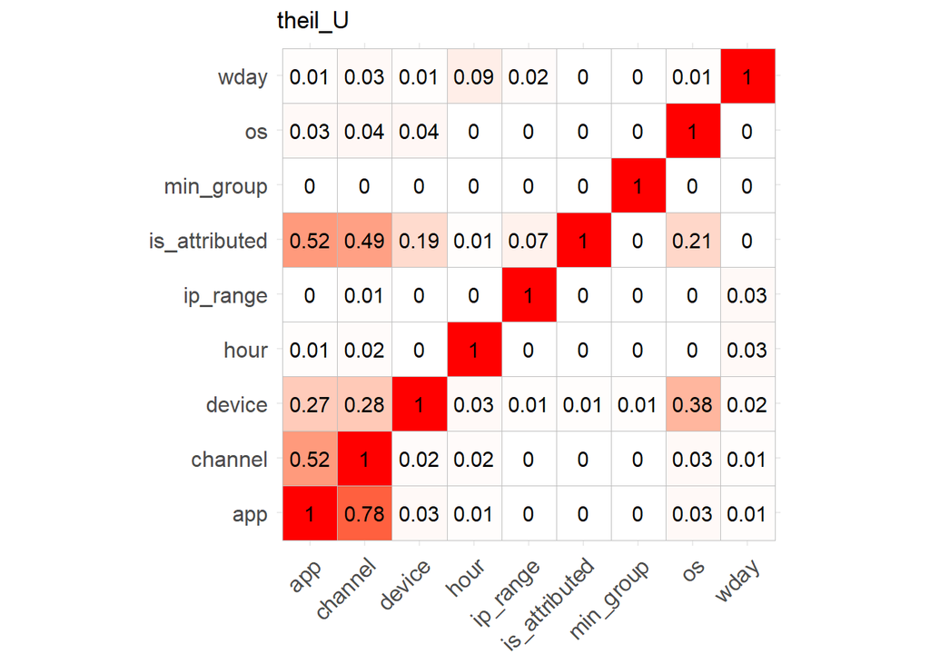

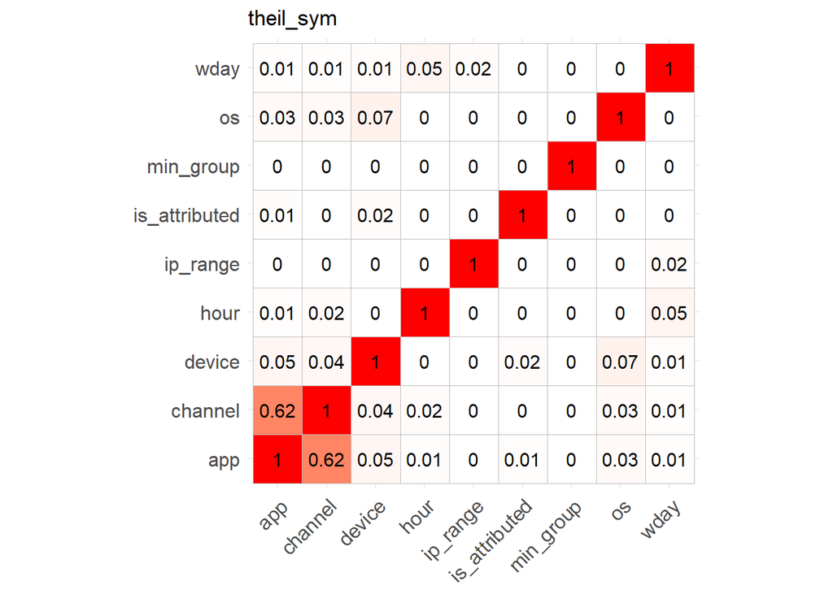

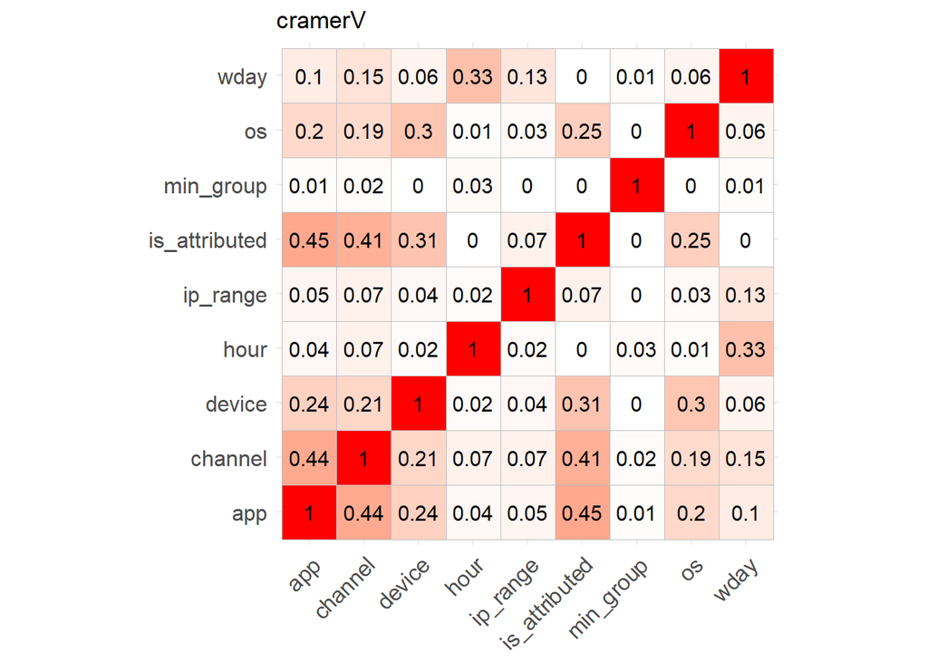

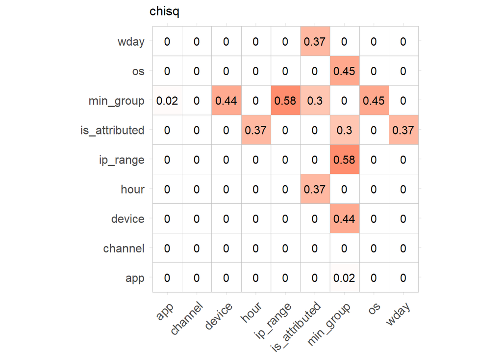

```
## [1] "Goodman's and Kruskal's tau"
```

[output not shown]

[output cut: 16 more lines]

[output not shown]

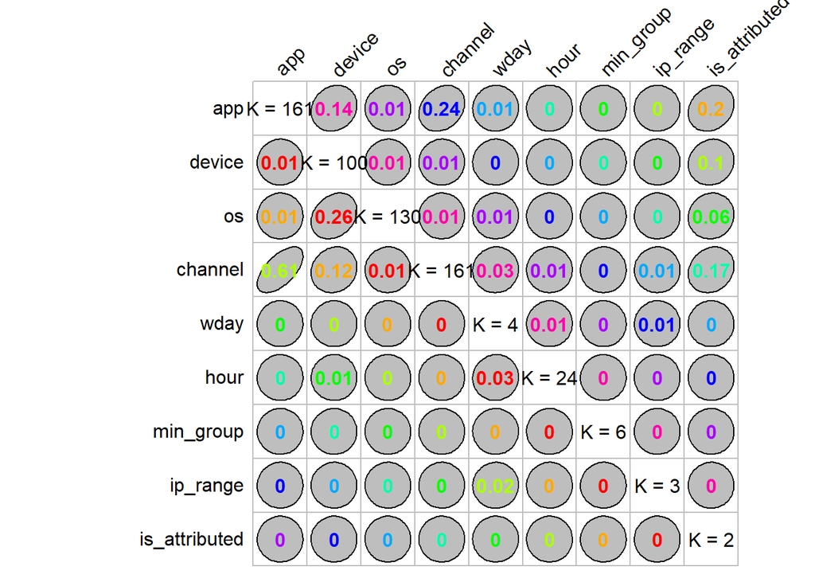

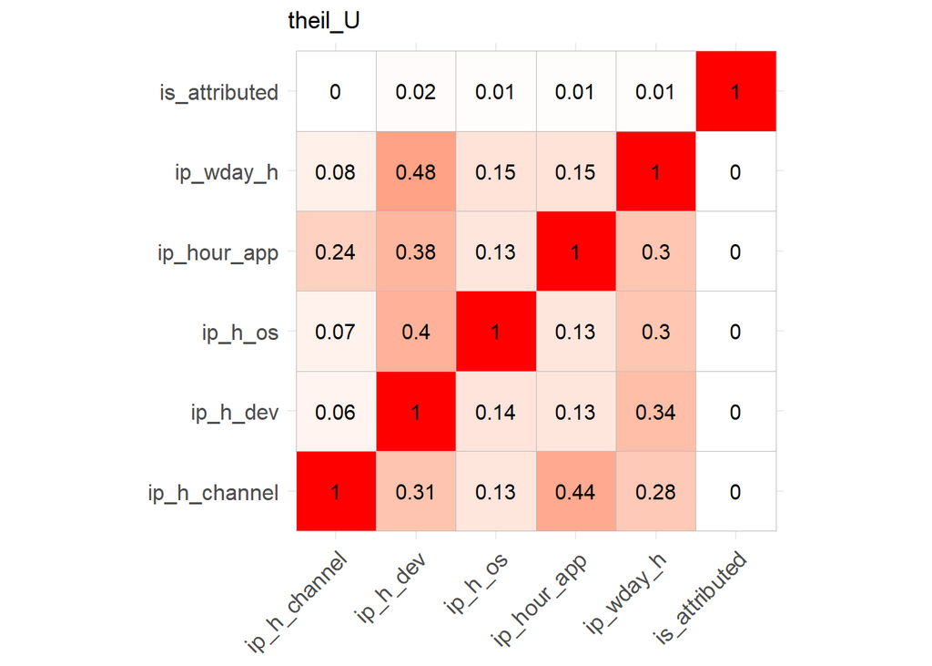

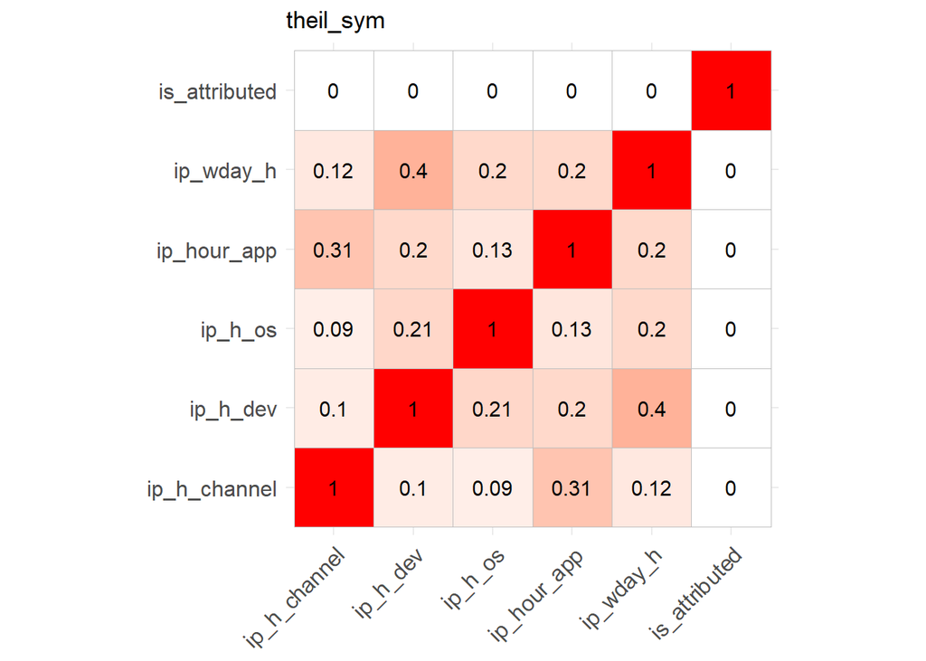

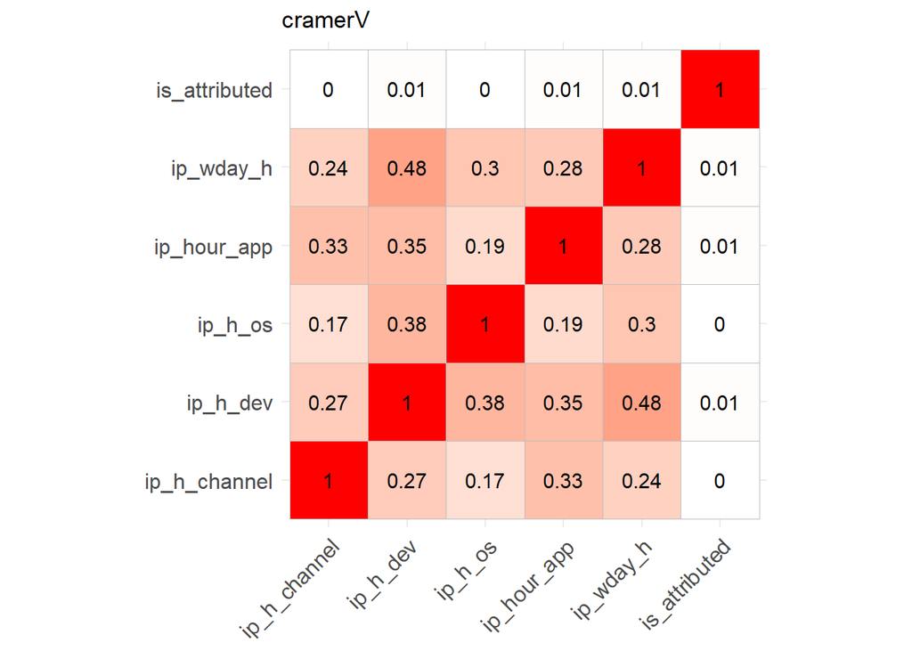